# Survey fish availability: CTS and IBTS exploration

Author

Monica Mion & Max Lindmark

Published

April 16, 2026

## Purpose

This notebook explores the cleaned fish-survey data before any modelling.

The main goals are to:

- understand what IBTS and coastal trawl surveys sample in space and time
- identify the dominant fish families and species
- decide which families and species are suitable for spatiotemporal modelling

## Load libraries

```r
library(tidyverse)
library(sf)
library(RColorBrewer)
library(scales)
library(patchwork)
library(rnaturalearth)

theme_set(theme_light())

home <- here::here()
```

## Read cleaned survey data

```r
family_dat <- read_csv(paste0(home, "/Data/survey/survey_family_model_data.csv"), show_col_types = FALSE)
species_dat <- read_csv(paste0(home, "/Data/survey/survey_species_model_data.csv"), show_col_types = FALSE)

family_dat
```

```
# A tibble: 4,935 × 15
   haul_id     year year_f year_ct quarter quarter_f survey survey_f   lat   lon
   <chr>      <dbl>  <dbl>   <dbl>   <dbl>     <dbl> <chr>  <chr>    <dbl> <dbl>
 1 2013_1_OX…  2013   2013       0       1         1 IBTS   IBTS      57.6  11.0
 2 2013_1_OX…  2013   2013       0       1         1 IBTS   IBTS      57.6  11.0
 3 2013_1_OX…  2013   2013       0       1         1 IBTS   IBTS      57.6  11.0
 4 2013_1_OX…  2013   2013       0       1         1 IBTS   IBTS      57.6  11.0
 5 2013_1_OX…  2013   2013       0       1         1 IBTS   IBTS      57.6  11.0
 6 2013_1_OX…  2013   2013       0       1         1 IBTS   IBTS      57.8  11.0
 7 2013_1_OX…  2013   2013       0       1         1 IBTS   IBTS      57.8  11.0
 8 2013_1_OX…  2013   2013       0       1         1 IBTS   IBTS      57.8  11.0
 9 2013_1_OX…  2013   2013       0       1         1 IBTS   IBTS      57.8  11.0
10 2013_1_OX…  2013   2013       0       1         1 IBTS   IBTS      57.8  11.0
# ℹ 4,925 more rows
# ℹ 5 more variables: X <dbl>, Y <dbl>, family <chr>, family_f <chr>,
#   catch_kg_km2 <dbl>
```

```r
species_dat
```

```
# A tibble: 43,123 × 17
   haul_id     year year_f year_ct quarter quarter_f survey survey_f   lat   lon
   <chr>      <dbl>  <dbl>   <dbl>   <dbl>     <dbl> <chr>  <chr>    <dbl> <dbl>
 1 2013_1_OX…  2013   2013       0       1         1 IBTS   IBTS      57.9  9.89
 2 2013_1_OX…  2013   2013       0       1         1 IBTS   IBTS      57.9  9.89
 3 2013_1_OX…  2013   2013       0       1         1 IBTS   IBTS      57.9  9.89
 4 2013_1_OX…  2013   2013       0       1         1 IBTS   IBTS      57.9  9.89
 5 2013_1_OX…  2013   2013       0       1         1 IBTS   IBTS      57.9  9.89
 6 2013_1_OX…  2013   2013       0       1         1 IBTS   IBTS      57.9  9.89
 7 2013_1_OX…  2013   2013       0       1         1 IBTS   IBTS      57.9  9.89
 8 2013_1_OX…  2013   2013       0       1         1 IBTS   IBTS      57.9  9.89
 9 2013_1_OX…  2013   2013       0       1         1 IBTS   IBTS      57.9  9.89
10 2013_1_OX…  2013   2013       0       1         1 IBTS   IBTS      57.9  9.89
# ℹ 43,113 more rows
# ℹ 7 more variables: X <dbl>, Y <dbl>, species <chr>, species_f <chr>,
#   family <chr>, family_f <chr>, catch_kg_km2 <dbl>
```

## Key data note

Clupeidae are treated differently from the other families: - they are well represented in IBTS, but they are not reliably recorded in the coastal survey (CTS).

This means:

- CTS Clupeidae values should not be interpreted as real zeros,
- Clupeidae must be modelled using IBTS only,
- joint IBTS + CTS models are appropriate for families that are recorded in both surveys, such as Gadidae and Pleuronectidae.

## Quick dataset summary

```r
list(
  family_rows = nrow(family_dat),
  species_rows = nrow(species_dat),
  n_hauls = n_distinct(family_dat$haul_id),
  family_levels = sort(unique(family_dat$family)),
  year_range = range(family_dat$year),
  quarters = sort(unique(family_dat$quarter)),
  surveys = sort(unique(family_dat$survey))
)
```

```
$family_rows
[1] 4935

$species_rows
[1] 43123

$n_hauls
[1] 987

$family_levels
[1] "Clupeidae"      "Gadidae"        "Other"          "Pleuronectidae"
[5] "Scombridae"

$year_range
[1] 2013 2024

$quarters
[1] 1 3

$surveys
[1] "CTS"  "IBTS"
```

## Sampling coverage in time

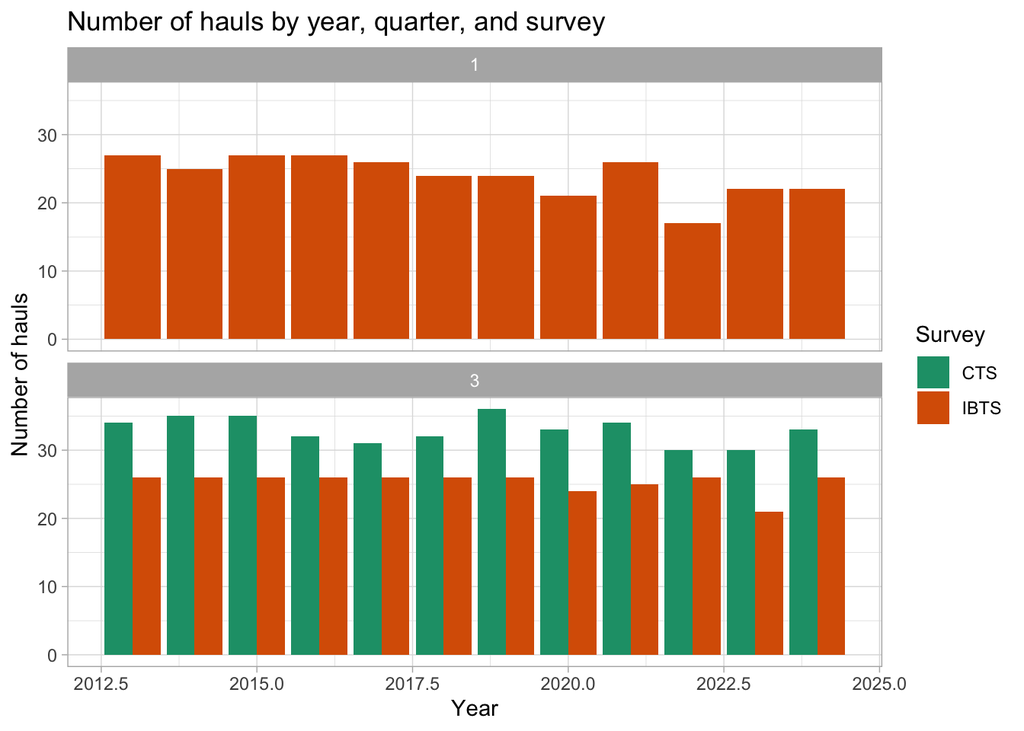

```r
haul_counts <- family_dat |>
  distinct(haul_id, year, quarter, survey) |>
  count(year, quarter, survey)

ggplot(haul_counts, aes(year, n, fill = survey)) +
  geom_col(position = "dodge") +
  facet_wrap(~quarter, ncol = 1) +
  scale_fill_brewer(palette = "Dark2") +
  labs(
    title = "Number of hauls by year, quarter, and survey",
    x = "Year",
    y = "Number of hauls",
    fill = "Survey"
  )
```

CTS is done in Q3, while IBTS in Q1 and Q3

[figure not shown]

## Spatial coverage through time

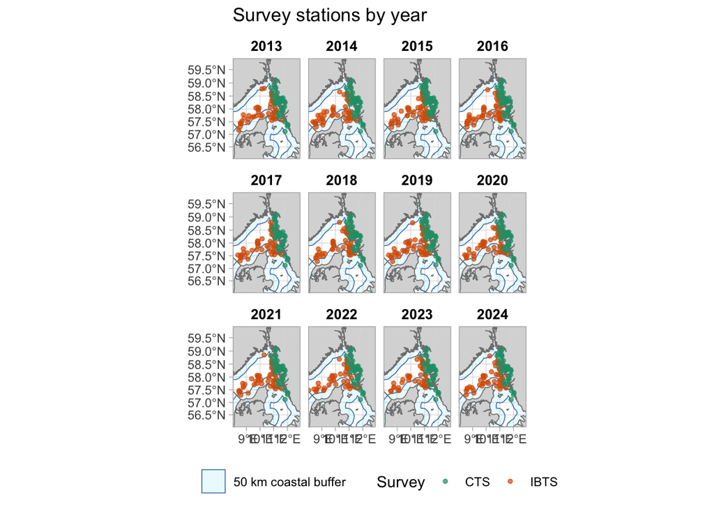

```r
map_all <- family_dat |>
  distinct(haul_id, year, survey, lat, lon)

ices_areas <- st_read(
  paste0(home, "/Data/shapefiles/ICES_areas/ICES_Areas_20160601_cut_dense_3857.shp"),
  quiet = TRUE
)

ices_crs <- st_crs("EPSG:3857")

# Land — crop first in degrees, then reproject
world <- ne_countries(scale = "medium", returnclass = "sf")
world_crop <- st_crop(world, c(xmin = 8, xmax = 13, ymin = 56, ymax = 60))
world_crop_3857 <- st_transform(world_crop, crs = ices_crs)

# Reproject ICES and crop to land extent
ices_areas_3857 <- st_transform(ices_areas, crs = ices_crs)
ices_crop_3857  <- st_crop(ices_areas_3857, st_bbox(world_crop_3857))

# Union land and create 50 km coastal buffer
land_union <- st_union(world_crop_3857)
land_50km  <- st_buffer(land_union, dist = 50000)

# Survey points
pts_all <- st_as_sf(map_all, coords = c("lon", "lat"), crs = 4326)
pts_all_3857 <- st_transform(pts_all, crs = ices_crs)

# Map with facets by year
ggplot() +
  geom_sf(data = land_50km, aes(fill = "50 km coastal buffer"),
          alpha = 0.3, colour = "steelblue", linewidth = 0.3) +
  geom_sf(data = world_crop_3857, fill = "grey85", colour = NA) +
  geom_sf(data = ices_crop_3857, fill = NA, colour = "grey50", linewidth = 0.3) +
  geom_sf(data = pts_all_3857, aes(colour = survey), size = 1.8, alpha = 0.7, shape = 20) +
  scale_color_brewer(palette = "Dark2") +
  scale_fill_manual(values = "lightblue1", guide = guide_legend(order = 1)) +
  coord_sf(
    xlim = xlim_3857,
    ylim = ylim_3857,
    expand = FALSE
  ) +
  facet_wrap(~year, ncol = 4) +
  labs(
    title = "Survey stations by year",
    x = NULL, y = NULL,
    colour = "Survey",
    fill = NULL
  ) +
  theme_light() +
  theme(
    panel.background = element_rect(fill = "white", colour = NA),
    legend.position = "bottom",
    strip.background = element_blank(),
    strip.text = element_text(colour = "black", face = "bold", size = 10)
  )
```

## Family-level composition

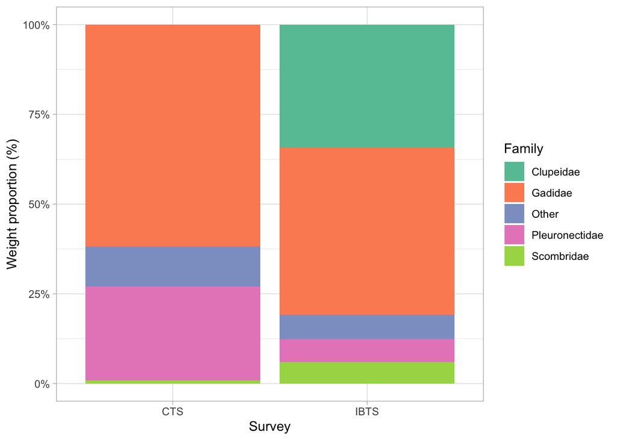

```r
family_share <- family_dat |>
  group_by(survey, family) |>
  summarise(total = sum(catch_kg_km2), .groups = "drop_last") |>
  mutate(prop = total / sum(total)) |>
  ungroup()

ggplot(family_share, aes(survey, prop, fill = family)) +
  geom_col() +
  scale_y_continuous(labels = percent_format()) +
  scale_fill_brewer(palette = "Set2") +
  labs(
   # title = "Family composition by survey",
    x = "Survey",
    y = "Weight proportion (%)",
    fill = "Family"
  )
```

## Family-level yearly composition

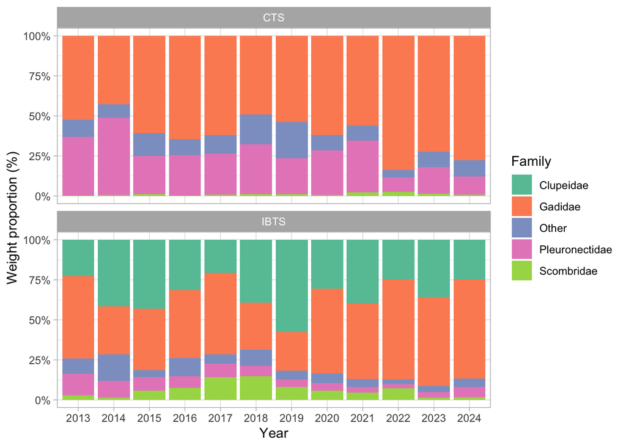

```r
family_share_year <- family_dat |>
  group_by(year, survey, family) |>
  summarise(total = sum(catch_kg_km2), .groups = "drop_last") |>
  mutate(prop = total / sum(total)) |>
  ungroup()

ggplot(family_share_year, aes(as.factor(year), prop, fill = family)) +
  geom_col() +
  facet_wrap(~survey, ncol = 1) +
  scale_y_continuous(labels = percent_format()) +
  scale_fill_brewer(palette = "Set2") +
  labs(
   # title = "Family composition through time",
    x = "Year",
    y = "Weight proportion (%)",
    fill = "Family"
  )
```

# Family weight proportion by year, quarter and survey

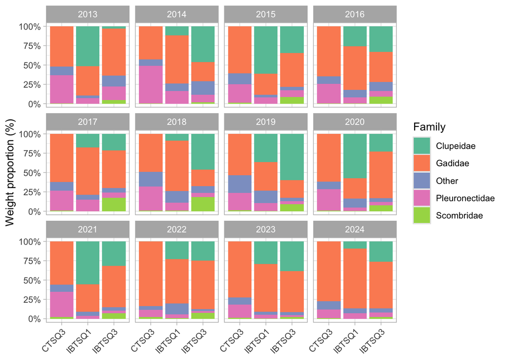

```r
family_share <- family_dat |>
  mutate(survey_quarter = paste(survey, "Q", quarter, sep = "")) |>
  group_by(year, survey_quarter, family) |>
  summarise(total = sum(catch_kg_km2), .groups = "drop_last") |>
  mutate(prop = total / sum(total)) |>
  ungroup()

ggplot(family_share, aes(survey_quarter, prop, fill = family)) +
  geom_col(position = "stack") +
  scale_y_continuous(labels = percent_format()) +
  scale_fill_brewer(palette = "Set2") +
  facet_wrap(~year) +
  labs(
    #title = "Family weight proportion by year, quarter and survey",
    x = NULL,
    y = "Weight proportion (%)",
    fill = "Family"
  ) +
  theme_light() +
  theme(
    axis.text.x = element_text(angle = 45, hjust = 1),
    panel.background = element_rect(fill = "white", colour = "grey90")
  )
```

## Zero rates by family

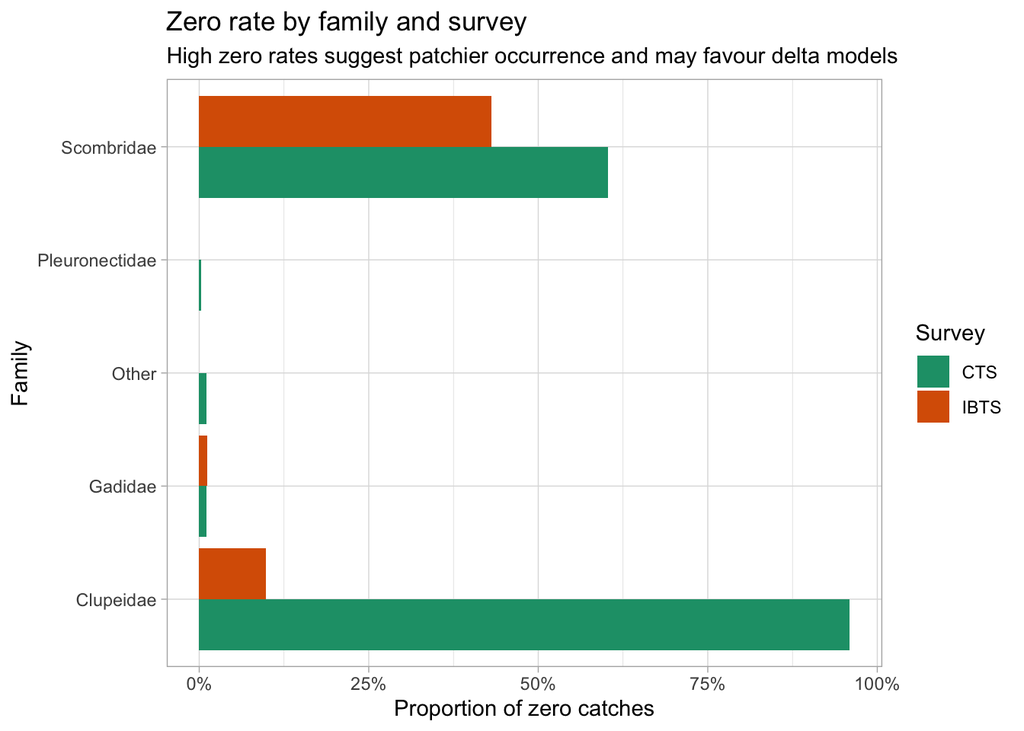

```r
family_zero <- family_dat |>
  group_by(survey, family) |>
  summarise(zero_rate = mean(catch_kg_km2 == 0), .groups = "drop")

ggplot(family_zero, aes(family, zero_rate, fill = survey)) +
  geom_col(position = "dodge") +
  scale_y_continuous(labels = percent_format()) +
  scale_fill_brewer(palette = "Dark2") +
  labs(
    title = "Zero rate by family and survey",
    subtitle = "High zero rates suggest patchier occurrence and may favour delta models",
    x = "Family",
    y = "Proportion of zero catches",
    fill = "Survey"
  ) +
  coord_flip()
```

## Interpretation

- Families with very low zero rates are nearly always present when recorded.
- Families with high zero rates may be patchier and more difficult to model. Gadidae and Pleuronectidae are strong candidates because they are common and broadly observed.

## Family-level mean density by year

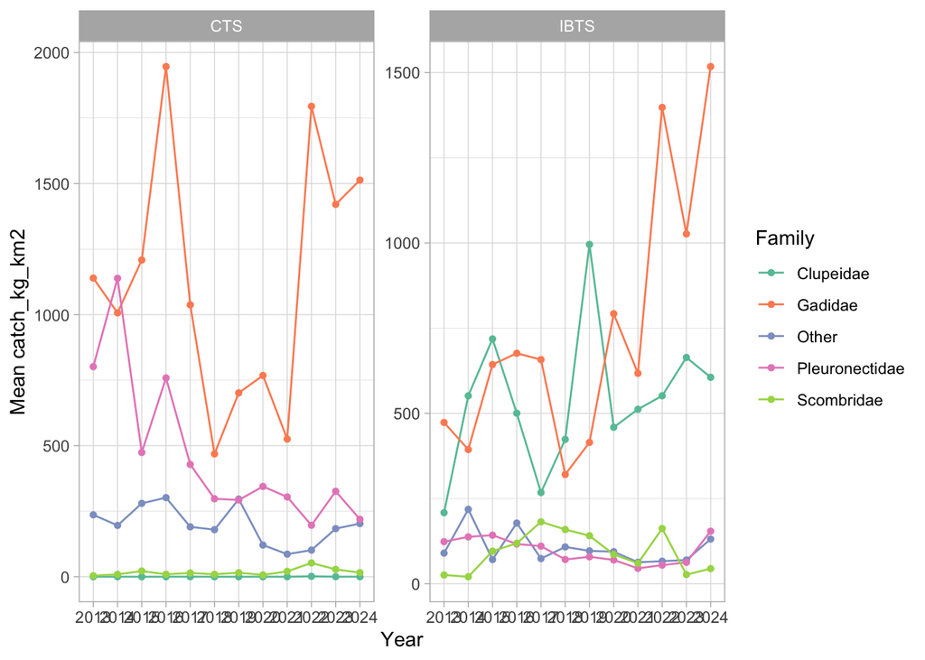

```r
family_mean <- family_dat |>
  group_by(year, survey, family) |>
  summarise(mean_catch = mean(catch_kg_km2), .groups = "drop")

family_mean |>
  ggplot(aes(as.factor(year), mean_catch,
              colour = family, group = family)) +
  geom_line() +
  geom_point(size = 1.2) +
  facet_wrap(~survey, scales = "free_y") +
  scale_color_brewer(palette = "Set2") +
  labs(
    x = "Year",
    y = "Mean catch_kg_km2",
    colour = "Family"
  )
```

## Species-level support

```r
top_species <- species_dat |>
  group_by(species, family) |>
  summarise(
    total = sum(catch_kg_km2),
    n_hauls = n_distinct(haul_id),
    .groups = "drop"
  ) |>
  arrange(desc(total))

top_species |> slice_head(n = 20)
```

```
# A tibble: 20 × 4
   species                      family           total n_hauls
   <chr>                        <chr>            <dbl>   <int>
 1 merlangius_merlangus         Gadidae        430433.     955
 2 clupea_harengus              Clupeidae      237299.     530
 3 melanogrammus_aeglefinus     Gadidae        181522.     753
 4 gadus_morhua                 Gadidae        143224.     886
 5 limanda_limanda              Pleuronectidae 141193.     819
 6 sprattus_sprattus            Clupeidae       78960.     290
 7 scomber_scombrus             Scombridae      62061.     494
 8 trisopterus_esmarkii         Gadidae         48364.     489
 9 pleuronectes_platessa        Pleuronectidae  39855.     885
10 squalus_acanthias            Squalidae       33634.     184
11 micromesistius_poutassou     Gadidae         33290.     108
12 pollachius_virens            Gadidae         30879.     352
13 hippoglossoides_platessoides Pleuronectidae  25077.     770
14 platichthys_flesus           Pleuronectidae  22137.     283
15 trachurus_trachurus          Carangidae      15672.     458
16 merluccius_merluccius        Merlucciidae    15228.     612
17 eutrigla_gurnardus           Triglidae       11892.     610
18 amblyraja_radiata            Rajidae          9661.     282
19 myoxocephalus_scorpius       Cottidae         8076.     215
20 trachinus_draco              Trachinidae      7869.     197
```

## Species-level composition

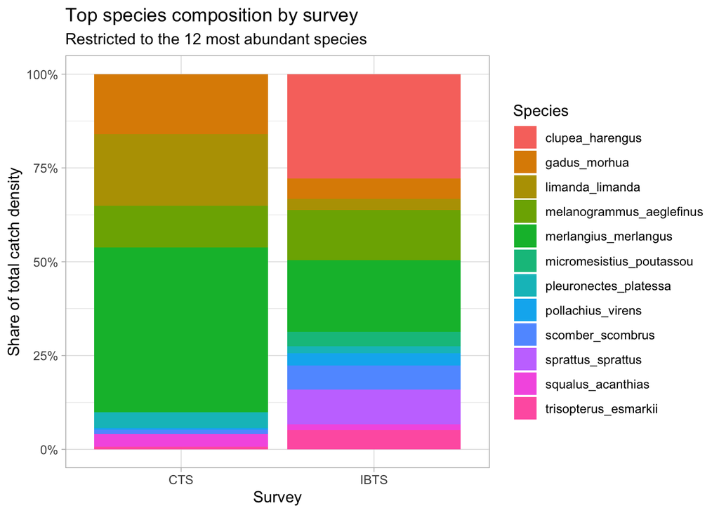

```r
top_species_names <- top_species |> slice_head(n = 12) |> pull(species)

species_share <- species_dat |>
  filter(species %in% top_species_names) |>
  group_by(survey, species) |>
  summarise(total = sum(catch_kg_km2), .groups = "drop_last") |>
  mutate(prop = total / sum(total)) |>
  ungroup()

ggplot(species_share, aes(survey, prop, fill = species)) +
  geom_col() +
  scale_y_continuous(labels = percent_format()) +
  labs(
    title = "Top species composition by survey",
    subtitle = "Restricted to the 12 most abundant species",
    x = "Survey",
    y = "Share of total catch density",
    fill = "Species"
  )
```

## Species-level mean density by year

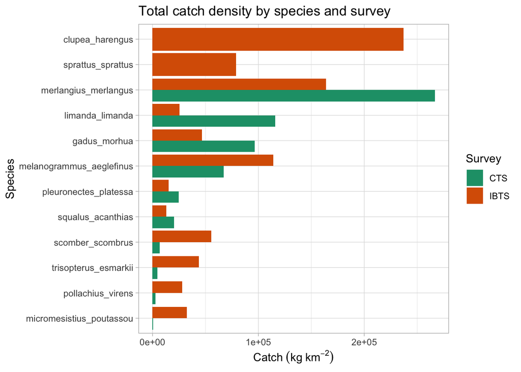

```r
top_species_names <- top_species |> slice_head(n = 12) |> pull(species)
species_dat |>
  filter(species %in% top_species_names) |>
  group_by(survey, species) |>
  summarise(total = sum(catch_kg_km2), .groups = "drop_last") |>
  mutate(species = reorder(species, total)) |>
  ggplot(aes(species, total, fill = survey)) +
  geom_col(position = "dodge") +
  coord_flip() +
  scale_fill_brewer(palette = "Dark2") +
  labs(
    title = "Total catch density by species and survey",
    x = "Species",
    y = expression(Catch ~ (kg ~ km^{-2})),
    fill = "Survey"
  )
```

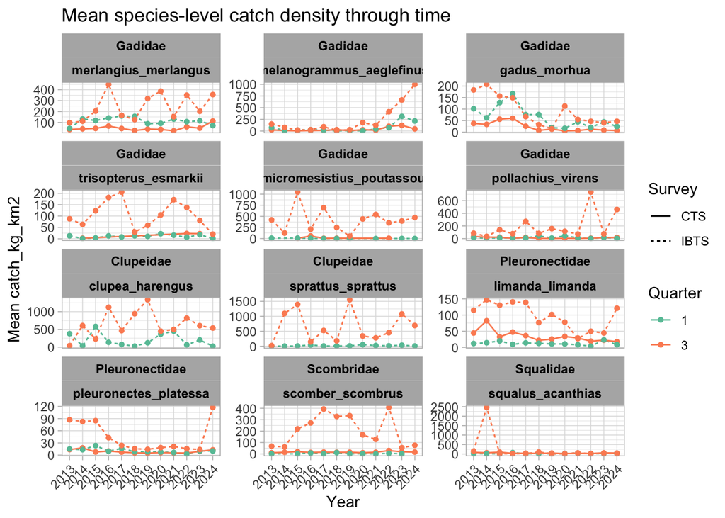

```r
top_species_names <- top_species |> slice_head(n = 12) |> pull(species)

  species_share <- species_dat |>
 filter(species %in% top_species_names) |>
  group_by(survey, species) |>
  summarise(total = sum(catch_kg_km2), .groups = "drop_last") |>
  mutate(prop = total / sum(total)) |>
  ungroup()

species_mean <- species_dat |>
  group_by(year, survey, quarter, family, species) |>
  summarise(mean_catch = mean(catch_kg_km2), .groups = "drop")


species_mean |>
  mutate(
    family  = factor(family,  levels = c("Gadidae", "Clupeidae", "Pleuronectidae", "Carangidae", "Scombridae", "Squalidae")),
    species = factor(species, levels = top_species_names)
  ) |>
  filter(species %in% top_species_names) |>
  ggplot(aes(as.factor(year), mean_catch,
              colour = as.factor(quarter),
              linetype = survey,
              group = interaction(survey, quarter))) +
  geom_line() +
  geom_point(size = 1.2) +
  facet_wrap(~ family + species, ncol = 3, scales = "free_y") +
  #scale_y_log10() +
  scale_color_brewer(palette = "Set2") +
  labs(
    title = "Mean species-level catch density through time",
    x = "Year",
    y = "Mean catch_kg_km2",
    colour = "Quarter",
    linetype = "Survey"
  ) +
  theme(
    axis.text.x = element_text(angle = 45, hjust = 1),
    strip.text = element_text(colour = "black", face = "bold")
  )
```

## Candidate targets for modelling

```r
family_candidates <- family_dat |>
  group_by(family) |>
  summarise(
    total = sum(catch_kg_km2),
    n_hauls = n_distinct(haul_id),
    zero_rate = mean(catch_kg_km2 == 0),
    surveys = paste(sort(unique(survey)), collapse = ", "),
    .groups = "drop"
  ) |>
  arrange(desc(total))

family_candidates
```

```
# A tibble: 5 × 5
  family           total n_hauls zero_rate surveys
  <chr>            <dbl>   <int>     <dbl> <chr>
1 Gadidae        870840.     987   0.0111  CTS, IBTS
2 Clupeidae      316814.     987   0.443   CTS, IBTS
3 Pleuronectidae 244344.     987   0.00101 CTS, IBTS
4 Other          141543.     987   0.00405 CTS, IBTS
5 Scombridae      62061.     987   0.499   CTS, IBTS
```

```r
species_candidates <- species_dat |>
  group_by(species, family) |>
  summarise(
    total = sum(catch_kg_km2),
    n_hauls = n_distinct(haul_id),
    years = n_distinct(year),
    surveys = paste(sort(unique(survey)), collapse = ", "),
    .groups = "drop"
  ) |>
  arrange(desc(total))

species_candidates |> slice_head(n = 20)
```

```
# A tibble: 20 × 6
   species                      family           total n_hauls years surveys
   <chr>                        <chr>            <dbl>   <int> <int> <chr>
 1 merlangius_merlangus         Gadidae        430433.     955    12 CTS, IBTS
 2 clupea_harengus              Clupeidae      237299.     530    12 IBTS
 3 melanogrammus_aeglefinus     Gadidae        181522.     753    12 CTS, IBTS
 4 gadus_morhua                 Gadidae        143224.     886    12 CTS, IBTS
 5 limanda_limanda              Pleuronectidae 141193.     819    12 CTS, IBTS
 6 sprattus_sprattus            Clupeidae       78960.     290    12 IBTS
 7 scomber_scombrus             Scombridae      62061.     494    12 CTS, IBTS
 8 trisopterus_esmarkii         Gadidae         48364.     489    12 CTS, IBTS
 9 pleuronectes_platessa        Pleuronectidae  39855.     885    12 CTS, IBTS
10 squalus_acanthias            Squalidae       33634.     184    12 CTS, IBTS
11 micromesistius_poutassou     Gadidae         33290.     108    12 CTS, IBTS
12 pollachius_virens            Gadidae         30879.     352    12 CTS, IBTS
13 hippoglossoides_platessoides Pleuronectidae  25077.     770    12 CTS, IBTS
14 platichthys_flesus           Pleuronectidae  22137.     283    12 CTS, IBTS
15 trachurus_trachurus          Carangidae      15672.     458    12 CTS, IBTS
16 merluccius_merluccius        Merlucciidae    15228.     612    12 CTS, IBTS
17 eutrigla_gurnardus           Triglidae       11892.     610    12 CTS, IBTS
18 amblyraja_radiata            Rajidae          9661.     282    12 CTS, IBTS
19 myoxocephalus_scorpius       Cottidae         8076.     215    12 CTS, IBTS
20 trachinus_draco              Trachinidae      7869.     197    12 CTS, IBTS
```